# **Home Credit Default Risk Project **

```python
import pandas as pd
import numpy as np
import matplotlib.pyplot as plt
import seaborn as sns
from sklearn.model_selection import train_test_split, GridSearchCV, cross_val_score
from sklearn.preprocessing import StandardScaler, OneHotEncoder, FunctionTransformer
from sklearn.impute import SimpleImputer
from sklearn.compose import ColumnTransformer
from sklearn.pipeline import Pipeline
from sklearn.linear_model import LogisticRegression
from sklearn.ensemble import RandomForestClassifier, GradientBoostingClassifier
from sklearn.base import clone
from sklearn.metrics import accuracy_score, roc_auc_score, f1_score, confusion_matrix, classification_report
import joblib
from sklearn.base import BaseEstimator, TransformerMixin, clone
from sklearn.feature_selection import SelectFromModel
```

## **Data Loading**

```python
'''#from google.colab import files
#files.upload()
!mkdir -p ~/.kaggle
!cp kaggle.json ~/.kaggle/
!chmod 600 ~/.kaggle/kaggle.json
!kaggle competitions download -c home-credit-default-risk
!unzip home-credit-default-risk.zip -d home_credit_data'''
```

```
'#from google.colab import files\n#files.upload()\n!mkdir -p ~/.kaggle\n!cp kaggle.json ~/.kaggle/\n!chmod 600 ~/.kaggle/kaggle.json\n!kaggle competitions download -c home-credit-default-risk\n!unzip home-credit-default-risk.zip -d home_credit_data'
```

```python
# Access the individual DataFrames using their filenames
application_train = pd.read_csv('application_train.csv')
bureau = pd.read_csv('bureau.csv')
bureau_balance = pd.read_csv('bureau_balance.csv')
application_test= pd.read_csv('application_test.csv')
credit_card_balance = pd.read_csv('credit_card_balance.csv')
installments_payments = pd.read_csv('installments_payments.csv')
previous_applications = pd.read_csv('previous_application.csv')
sample_submission = pd.read_csv('sample_submission.csv')
POS_Cash_balance = pd.read_csv('POS_CASH_balance.csv')
HomeCredit_columns_description = pd.read_csv('HomeCredit_columns_description.csv', encoding='unicode_escape')
```

## **Glimpse the data**

```python
HomeCredit_columns_description.head()
```

|  | Unnamed: 0 | Table | Row | Description | Special |
| --- | --- | --- | --- | --- | --- |
| 0 | 1 | application_{train\|test}.csv | SK_ID_CURR | ID of loan in our sample | NaN |
| 1 | 2 | application_{train\|test}.csv | TARGET | Target variable (1 - client with payment diffi... | NaN |
| 2 | 5 | application_{train\|test}.csv | NAME_CONTRACT_TYPE | Identification if loan is cash or revolving | NaN |
| 3 | 6 | application_{train\|test}.csv | CODE_GENDER | Gender of the client | NaN |
| 4 | 7 | application_{train\|test}.csv | FLAG_OWN_CAR | Flag if the client owns a car | NaN |

```python
application_train.head()
```

|  | SK_ID_CURR | TARGET | NAME_CONTRACT_TYPE | CODE_GENDER | FLAG_OWN_CAR | FLAG_OWN_REALTY | CNT_CHILDREN | AMT_INCOME_TOTAL | AMT_CREDIT | AMT_ANNUITY | ... | FLAG_DOCUMENT_18 | FLAG_DOCUMENT_19 | FLAG_DOCUMENT_20 | FLAG_DOCUMENT_21 | AMT_REQ_CREDIT_BUREAU_HOUR | AMT_REQ_CREDIT_BUREAU_DAY | AMT_REQ_CREDIT_BUREAU_WEEK | AMT_REQ_CREDIT_BUREAU_MON | AMT_REQ_CREDIT_BUREAU_QRT | AMT_REQ_CREDIT_BUREAU_YEAR |
| --- | --- | --- | --- | --- | --- | --- | --- | --- | --- | --- | --- | --- | --- | --- | --- | --- | --- | --- | --- | --- | --- |
| 0 | 100002 | 1 | Cash loans | M | N | Y | 0 | 202500.0 | 406597.5 | 24700.5 | ... | 0 | 0 | 0 | 0 | 0.0 | 0.0 | 0.0 | 0.0 | 0.0 | 1.0 |
| 1 | 100003 | 0 | Cash loans | F | N | N | 0 | 270000.0 | 1293502.5 | 35698.5 | ... | 0 | 0 | 0 | 0 | 0.0 | 0.0 | 0.0 | 0.0 | 0.0 | 0.0 |
| 2 | 100004 | 0 | Revolving loans | M | Y | Y | 0 | 67500.0 | 135000.0 | 6750.0 | ... | 0 | 0 | 0 | 0 | 0.0 | 0.0 | 0.0 | 0.0 | 0.0 | 0.0 |
| 3 | 100006 | 0 | Cash loans | F | N | Y | 0 | 135000.0 | 312682.5 | 29686.5 | ... | 0 | 0 | 0 | 0 | NaN | NaN | NaN | NaN | NaN | NaN |
| 4 | 100007 | 0 | Cash loans | M | N | Y | 0 | 121500.0 | 513000.0 | 21865.5 | ... | 0 | 0 | 0 | 0 | 0.0 | 0.0 | 0.0 | 0.0 | 0.0 | 0.0 |

5 rows × 122 columns

```python
application_train.shape
```

```
(307511, 122)
```

```python
application_test.shape
```

```
(48744, 121)
```

```python
bureau.head()
```

|  | SK_ID_CURR | SK_ID_BUREAU | CREDIT_ACTIVE | CREDIT_CURRENCY | DAYS_CREDIT | CREDIT_DAY_OVERDUE | DAYS_CREDIT_ENDDATE | DAYS_ENDDATE_FACT | AMT_CREDIT_MAX_OVERDUE | CNT_CREDIT_PROLONG | AMT_CREDIT_SUM | AMT_CREDIT_SUM_DEBT | AMT_CREDIT_SUM_LIMIT | AMT_CREDIT_SUM_OVERDUE | CREDIT_TYPE | DAYS_CREDIT_UPDATE | AMT_ANNUITY |
| --- | --- | --- | --- | --- | --- | --- | --- | --- | --- | --- | --- | --- | --- | --- | --- | --- | --- |
| 0 | 215354 | 5714462 | Closed | currency 1 | -497 | 0 | -153.0 | -153.0 | NaN | 0 | 91323.0 | 0.0 | NaN | 0.0 | Consumer credit | -131 | NaN |
| 1 | 215354 | 5714463 | Active | currency 1 | -208 | 0 | 1075.0 | NaN | NaN | 0 | 225000.0 | 171342.0 | NaN | 0.0 | Credit card | -20 | NaN |
| 2 | 215354 | 5714464 | Active | currency 1 | -203 | 0 | 528.0 | NaN | NaN | 0 | 464323.5 | NaN | NaN | 0.0 | Consumer credit | -16 | NaN |
| 3 | 215354 | 5714465 | Active | currency 1 | -203 | 0 | NaN | NaN | NaN | 0 | 90000.0 | NaN | NaN | 0.0 | Credit card | -16 | NaN |
| 4 | 215354 | 5714466 | Active | currency 1 | -629 | 0 | 1197.0 | NaN | 77674.5 | 0 | 2700000.0 | NaN | NaN | 0.0 | Consumer credit | -21 | NaN |

```python
bureau_balance.head()
```

|  | SK_ID_BUREAU | MONTHS_BALANCE | STATUS |
| --- | --- | --- | --- |
| 0 | 5715448 | 0 | C |
| 1 | 5715448 | -1 | C |
| 2 | 5715448 | -2 | C |
| 3 | 5715448 | -3 | C |
| 4 | 5715448 | -4 | C |

```python
application_test.head()
```

|  | SK_ID_CURR | NAME_CONTRACT_TYPE | CODE_GENDER | FLAG_OWN_CAR | FLAG_OWN_REALTY | CNT_CHILDREN | AMT_INCOME_TOTAL | AMT_CREDIT | AMT_ANNUITY | AMT_GOODS_PRICE | ... | FLAG_DOCUMENT_18 | FLAG_DOCUMENT_19 | FLAG_DOCUMENT_20 | FLAG_DOCUMENT_21 | AMT_REQ_CREDIT_BUREAU_HOUR | AMT_REQ_CREDIT_BUREAU_DAY | AMT_REQ_CREDIT_BUREAU_WEEK | AMT_REQ_CREDIT_BUREAU_MON | AMT_REQ_CREDIT_BUREAU_QRT | AMT_REQ_CREDIT_BUREAU_YEAR |
| --- | --- | --- | --- | --- | --- | --- | --- | --- | --- | --- | --- | --- | --- | --- | --- | --- | --- | --- | --- | --- | --- |
| 0 | 100001 | Cash loans | F | N | Y | 0 | 135000.0 | 568800.0 | 20560.5 | 450000.0 | ... | 0 | 0 | 0 | 0 | 0.0 | 0.0 | 0.0 | 0.0 | 0.0 | 0.0 |
| 1 | 100005 | Cash loans | M | N | Y | 0 | 99000.0 | 222768.0 | 17370.0 | 180000.0 | ... | 0 | 0 | 0 | 0 | 0.0 | 0.0 | 0.0 | 0.0 | 0.0 | 3.0 |
| 2 | 100013 | Cash loans | M | Y | Y | 0 | 202500.0 | 663264.0 | 69777.0 | 630000.0 | ... | 0 | 0 | 0 | 0 | 0.0 | 0.0 | 0.0 | 0.0 | 1.0 | 4.0 |
| 3 | 100028 | Cash loans | F | N | Y | 2 | 315000.0 | 1575000.0 | 49018.5 | 1575000.0 | ... | 0 | 0 | 0 | 0 | 0.0 | 0.0 | 0.0 | 0.0 | 0.0 | 3.0 |
| 4 | 100038 | Cash loans | M | Y | N | 1 | 180000.0 | 625500.0 | 32067.0 | 625500.0 | ... | 0 | 0 | 0 | 0 | NaN | NaN | NaN | NaN | NaN | NaN |

5 rows × 121 columns

```python
credit_card_balance.head()
```

|  | SK_ID_PREV | SK_ID_CURR | MONTHS_BALANCE | AMT_BALANCE | AMT_CREDIT_LIMIT_ACTUAL | AMT_DRAWINGS_ATM_CURRENT | AMT_DRAWINGS_CURRENT | AMT_DRAWINGS_OTHER_CURRENT | AMT_DRAWINGS_POS_CURRENT | AMT_INST_MIN_REGULARITY | ... | AMT_RECIVABLE | AMT_TOTAL_RECEIVABLE | CNT_DRAWINGS_ATM_CURRENT | CNT_DRAWINGS_CURRENT | CNT_DRAWINGS_OTHER_CURRENT | CNT_DRAWINGS_POS_CURRENT | CNT_INSTALMENT_MATURE_CUM | NAME_CONTRACT_STATUS | SK_DPD | SK_DPD_DEF |
| --- | --- | --- | --- | --- | --- | --- | --- | --- | --- | --- | --- | --- | --- | --- | --- | --- | --- | --- | --- | --- | --- |
| 0 | 2562384 | 378907 | -6 | 56.970 | 135000 | 0.0 | 877.5 | 0.0 | 877.5 | 1700.325 | ... | 0.000 | 0.000 | 0.0 | 1 | 0.0 | 1.0 | 35.0 | Active | 0 | 0 |
| 1 | 2582071 | 363914 | -1 | 63975.555 | 45000 | 2250.0 | 2250.0 | 0.0 | 0.0 | 2250.000 | ... | 64875.555 | 64875.555 | 1.0 | 1 | 0.0 | 0.0 | 69.0 | Active | 0 | 0 |
| 2 | 1740877 | 371185 | -7 | 31815.225 | 450000 | 0.0 | 0.0 | 0.0 | 0.0 | 2250.000 | ... | 31460.085 | 31460.085 | 0.0 | 0 | 0.0 | 0.0 | 30.0 | Active | 0 | 0 |
| 3 | 1389973 | 337855 | -4 | 236572.110 | 225000 | 2250.0 | 2250.0 | 0.0 | 0.0 | 11795.760 | ... | 233048.970 | 233048.970 | 1.0 | 1 | 0.0 | 0.0 | 10.0 | Active | 0 | 0 |
| 4 | 1891521 | 126868 | -1 | 453919.455 | 450000 | 0.0 | 11547.0 | 0.0 | 11547.0 | 22924.890 | ... | 453919.455 | 453919.455 | 0.0 | 1 | 0.0 | 1.0 | 101.0 | Active | 0 | 0 |

5 rows × 23 columns

```python
installments_payments.head()
```

|  | SK_ID_PREV | SK_ID_CURR | NUM_INSTALMENT_VERSION | NUM_INSTALMENT_NUMBER | DAYS_INSTALMENT | DAYS_ENTRY_PAYMENT | AMT_INSTALMENT | AMT_PAYMENT |
| --- | --- | --- | --- | --- | --- | --- | --- | --- |
| 0 | 1054186 | 161674 | 1.0 | 6 | -1180.0 | -1187.0 | 6948.360 | 6948.360 |
| 1 | 1330831 | 151639 | 0.0 | 34 | -2156.0 | -2156.0 | 1716.525 | 1716.525 |
| 2 | 2085231 | 193053 | 2.0 | 1 | -63.0 | -63.0 | 25425.000 | 25425.000 |
| 3 | 2452527 | 199697 | 1.0 | 3 | -2418.0 | -2426.0 | 24350.130 | 24350.130 |
| 4 | 2714724 | 167756 | 1.0 | 2 | -1383.0 | -1366.0 | 2165.040 | 2160.585 |

```python
previous_applications.head()
```

|  | SK_ID_PREV | SK_ID_CURR | NAME_CONTRACT_TYPE | AMT_ANNUITY | AMT_APPLICATION | AMT_CREDIT | AMT_DOWN_PAYMENT | AMT_GOODS_PRICE | WEEKDAY_APPR_PROCESS_START | HOUR_APPR_PROCESS_START | ... | NAME_SELLER_INDUSTRY | CNT_PAYMENT | NAME_YIELD_GROUP | PRODUCT_COMBINATION | DAYS_FIRST_DRAWING | DAYS_FIRST_DUE | DAYS_LAST_DUE_1ST_VERSION | DAYS_LAST_DUE | DAYS_TERMINATION | NFLAG_INSURED_ON_APPROVAL |
| --- | --- | --- | --- | --- | --- | --- | --- | --- | --- | --- | --- | --- | --- | --- | --- | --- | --- | --- | --- | --- | --- |
| 0 | 2030495 | 271877 | Consumer loans | 1730.430 | 17145.0 | 17145.0 | 0.0 | 17145.0 | SATURDAY | 15 | ... | Connectivity | 12.0 | middle | POS mobile with interest | 365243.0 | -42.0 | 300.0 | -42.0 | -37.0 | 0.0 |
| 1 | 2802425 | 108129 | Cash loans | 25188.615 | 607500.0 | 679671.0 | NaN | 607500.0 | THURSDAY | 11 | ... | XNA | 36.0 | low_action | Cash X-Sell: low | 365243.0 | -134.0 | 916.0 | 365243.0 | 365243.0 | 1.0 |
| 2 | 2523466 | 122040 | Cash loans | 15060.735 | 112500.0 | 136444.5 | NaN | 112500.0 | TUESDAY | 11 | ... | XNA | 12.0 | high | Cash X-Sell: high | 365243.0 | -271.0 | 59.0 | 365243.0 | 365243.0 | 1.0 |
| 3 | 2819243 | 176158 | Cash loans | 47041.335 | 450000.0 | 470790.0 | NaN | 450000.0 | MONDAY | 7 | ... | XNA | 12.0 | middle | Cash X-Sell: middle | 365243.0 | -482.0 | -152.0 | -182.0 | -177.0 | 1.0 |
| 4 | 1784265 | 202054 | Cash loans | 31924.395 | 337500.0 | 404055.0 | NaN | 337500.0 | THURSDAY | 9 | ... | XNA | 24.0 | high | Cash Street: high | NaN | NaN | NaN | NaN | NaN | NaN |

5 rows × 37 columns

```python
sample_submission.head()
```

|  | SK_ID_CURR | TARGET |
| --- | --- | --- |
| 0 | 100001 | 0.5 |
| 1 | 100005 | 0.5 |
| 2 | 100013 | 0.5 |
| 3 | 100028 | 0.5 |
| 4 | 100038 | 0.5 |

```python
POS_Cash_balance.head()
```

|  | SK_ID_PREV | SK_ID_CURR | MONTHS_BALANCE | CNT_INSTALMENT | CNT_INSTALMENT_FUTURE | NAME_CONTRACT_STATUS | SK_DPD | SK_DPD_DEF |
| --- | --- | --- | --- | --- | --- | --- | --- | --- |
| 0 | 1803195 | 182943 | -31 | 48.0 | 45.0 | Active | 0 | 0 |
| 1 | 1715348 | 367990 | -33 | 36.0 | 35.0 | Active | 0 | 0 |
| 2 | 1784872 | 397406 | -32 | 12.0 | 9.0 | Active | 0 | 0 |
| 3 | 1903291 | 269225 | -35 | 48.0 | 42.0 | Active | 0 | 0 |
| 4 | 2341044 | 334279 | -35 | 36.0 | 35.0 | Active | 0 | 0 |

```python
print("application_train -  rows:",application_train.shape[0]," columns:", application_train.shape[1])
print("application_test -  rows:",application_test.shape[0]," columns:", application_test.shape[1])
print("bureau -  rows:",bureau.shape[0]," columns:", bureau.shape[1])
print("bureau_balance -  rows:",bureau_balance.shape[0]," columns:", bureau_balance.shape[1])
print("credit_card_balance -  rows:",credit_card_balance.shape[0]," columns:", credit_card_balance.shape[1])
print("installments_payments -  rows:",installments_payments.shape[0]," columns:", installments_payments.shape[1])
print("previous_applications -  rows:",previous_applications.shape[0]," columns:", previous_applications.shape[1])
print("POS_CASH_balance -  rows:",POS_Cash_balance.shape[0]," columns:", POS_Cash_balance.shape[1])
```

```
application_train -  rows: 307511  columns: 122
application_test -  rows: 48744  columns: 121
bureau -  rows: 1716428  columns: 17
bureau_balance -  rows: 27299925  columns: 3
credit_card_balance -  rows: 3840312  columns: 23
installments_payments -  rows: 13605401  columns: 8
previous_applications -  rows: 1670214  columns: 37
POS_CASH_balance -  rows: 10001358  columns: 8
```

## **Data Preprocessing**

### Check Missing Values

```python
# Store the DataFrames in a dictionary
dataframes = {
    'application_train': application_train,
    'bureau': bureau,
    'bureau_balance': bureau_balance,
    'application_test': application_test,
    'credit_card_balance': credit_card_balance,
    'installments_payments': installments_payments,
    'previous_applications': previous_applications,
    'sample_submission': sample_submission,
    'POS_Cash_balance': POS_Cash_balance,
    'HomeCredit_columns_description': HomeCredit_columns_description
}

# Function to calculate missing values for a DataFrame
def calculate_missing_values(df):
    total = df.isnull().sum().sort_values(ascending=False)
    percent = (df.isnull().sum() / df.isnull().count() * 100).sort_values(ascending=False)
    missing_data = pd.concat([total, percent], axis=1, keys=['Total', 'Percent'])
    return missing_data.head(20)

# Iterate over the dictionary and print missing values for each DataFrame
for name, df in dataframes.items():
    print(f"Missing values for {name}:")
    print(calculate_missing_values(df), "\n")
```

```
Missing values for application_train:
                           Total    Percent
COMMONAREA_MEDI           214865  69.872297
COMMONAREA_AVG            214865  69.872297
COMMONAREA_MODE           214865  69.872297
NONLIVINGAPARTMENTS_MODE  213514  69.432963
NONLIVINGAPARTMENTS_AVG   213514  69.432963
NONLIVINGAPARTMENTS_MEDI  213514  69.432963
FONDKAPREMONT_MODE        210295  68.386172
LIVINGAPARTMENTS_MODE     210199  68.354953
LIVINGAPARTMENTS_AVG      210199  68.354953
LIVINGAPARTMENTS_MEDI     210199  68.354953
FLOORSMIN_AVG             208642  67.848630
FLOORSMIN_MODE            208642  67.848630
FLOORSMIN_MEDI            208642  67.848630
YEARS_BUILD_MEDI          204488  66.497784
YEARS_BUILD_MODE          204488  66.497784
YEARS_BUILD_AVG           204488  66.497784
OWN_CAR_AGE               202929  65.990810
LANDAREA_MEDI             182590  59.376738
LANDAREA_MODE             182590  59.376738
LANDAREA_AVG              182590  59.376738

Missing values for bureau:
                          Total    Percent
AMT_ANNUITY             1226791  71.473490
AMT_CREDIT_MAX_OVERDUE  1124488  65.513264
DAYS_ENDDATE_FACT        633653  36.916958
AMT_CREDIT_SUM_LIMIT     591780  34.477415
AMT_CREDIT_SUM_DEBT      257669  15.011932
DAYS_CREDIT_ENDDATE      105553   6.149573
AMT_CREDIT_SUM               13   0.000757
CREDIT_ACTIVE                 0   0.000000
CREDIT_CURRENCY               0   0.000000
DAYS_CREDIT                   0   0.000000
CREDIT_DAY_OVERDUE            0   0.000000
SK_ID_BUREAU                  0   0.000000
CNT_CREDIT_PROLONG            0   0.000000
AMT_CREDIT_SUM_OVERDUE        0   0.000000
CREDIT_TYPE                   0   0.000000
```

[output cut: 97 more lines]

```
CNT_INSTALMENT         26071  0.260675
SK_ID_PREV                 0  0.000000
SK_ID_CURR                 0  0.000000
MONTHS_BALANCE             0  0.000000
NAME_CONTRACT_STATUS       0  0.000000
SK_DPD                     0  0.000000
SK_DPD_DEF                 0  0.000000

Missing values for HomeCredit_columns_description:
             Total    Percent
Special        133  60.730594
Unnamed: 0       0   0.000000
Table            0   0.000000
Row              0   0.000000
Description      0   0.000000
```

## **Exploratory Data Analysis**

### 1. Get the count of unique values of SK_ID_CURR in file application_train.csv and compare this count to the number of rows in application_train.csv. Compare this with the total row count. Investigate if SK_ID_CURR serves as the table's primary key.?

```python
# Count of unique SK_ID_CURR values
unique_sk_id_curr_count = application_train['SK_ID_CURR'].nunique()

# Total number of rows
total_rows = application_train.shape[0]

# Determine if SK_ID_CURR is a primary key
is_primary_key = unique_sk_id_curr_count == total_rows

print(f"Unique SK_ID_CURR Count: {unique_sk_id_curr_count}")
print(f"Total Rows: {total_rows}")
print(f"Is SK_ID_CURR a Primary Key? {'Yes' if is_primary_key else 'No'}")
```

```
Unique SK_ID_CURR Count: 307511
Total Rows: 307511
Is SK_ID_CURR a Primary Key? Yes
```

Investigation: The analysis of the application_train.csv dataset reveals that the SK_ID_CURR column contains 307,511 unique entries, which matches the total row count of the dataset. This one-to-one correspondence confirms that each entry in the dataset is distinct, allowing SK_ID_CURR to effectively serve as the primary key. This finding is critical for data integrity and analysis, ensuring efficient data retrieval and relationship mapping in database management and analytical endeavors.

### 2.Identify and quantify the unique values within the TARGET column. Assess the dataset's balance by evaluating the proportions of each target value.

```python
unique_values = application_train['TARGET'].value_counts()
total_values = len(application_train['TARGET'])
for value, count in unique_values.items():
  percentage = (count / total_values) * 100
  print(f"Value: {value}, Count: {count}, Percentage: {percentage:.2f}%")
```

```
Value: 0, Count: 282686, Percentage: 91.93%
Value: 1, Count: 24825, Percentage: 8.07%
```

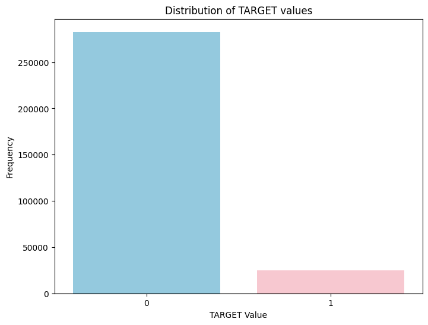

```python
# Visualization with a bar chart and different colors for each TARGET value
plt.figure(figsize=(8, 6))
sns.barplot(x=unique_values.index, y=unique_values.values, palette=['skyblue', 'pink'])
plt.title('Distribution of TARGET values')
plt.xlabel('TARGET Value')
plt.ylabel('Frequency')
plt.xticks(rotation=0)  # Keeps the x-axis labels horizontal
plt.show()
```

*Findings: Their are two unique categories in TARGET column: 0 and 1. 0 represents the loans which have been repayed whereas 1 represents the number of loans that are yet to be repayed. It can be clearly seen that the majority of the loans here in the training dataset are repayed. Only around 8.1% of the loans have not been repayed. We can further use this insight to analyze the loan repayers demographics, details about their loans such as loan type, loan amount, loan duration, interest rates etc to predict which loan taker is likely to repay their loans faster. We probably will have to undersample the class 0 otherwise we have a very imbalanced distribution which will cause issues while training the model.*

### 3.Correlation Analysis: Generate a Pearson correlation matrix and heatmap (for any 10 numeric variables of choice) on application_tain.csv. Write code to list the top 5 features correlated with the TARGET column.

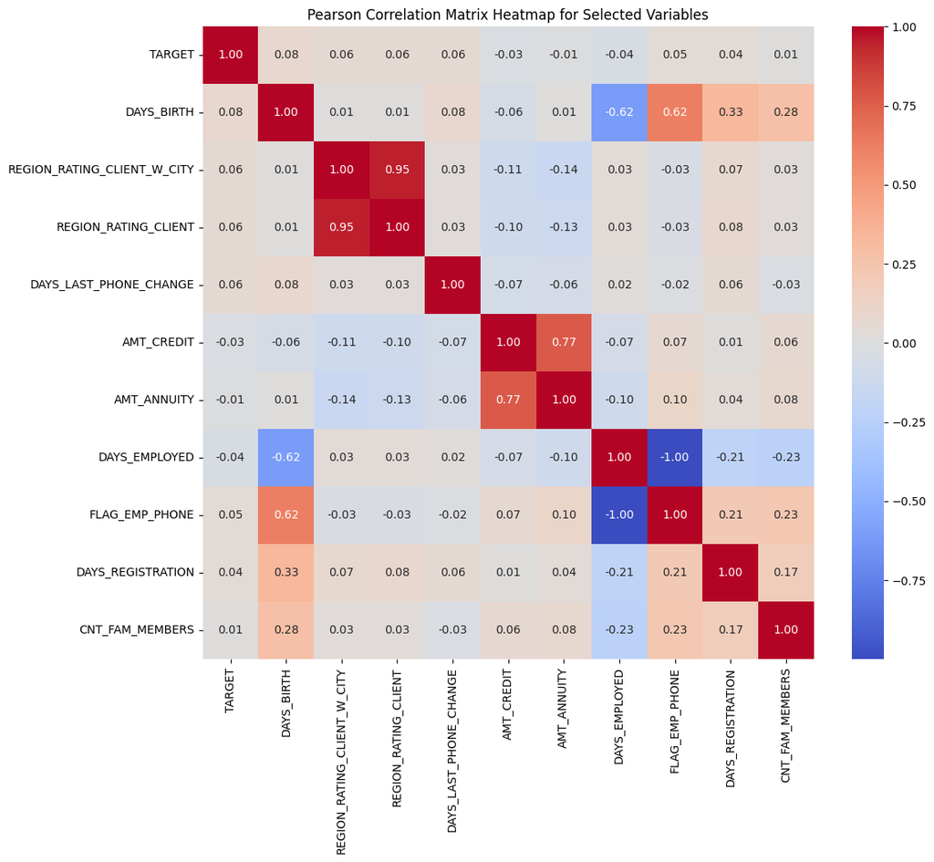

```
Top 5 features correlated with TARGET: DAYS_BIRTH                     0.078239
REGION_RATING_CLIENT_W_CITY    0.060893
REGION_RATING_CLIENT           0.058899
DAYS_LAST_PHONE_CHANGE         0.055218
FLAG_EMP_PHONE                 0.045982
Name: TARGET, dtype: float64
```

```python
#import random

# Select 10 numeric variables of choice from the application_train dataframe
numeric_columns = application_train.select_dtypes(include=[np.number]).columns.tolist()
selected_columns = ['TARGET',
                    'DAYS_BIRTH',
                    'REGION_RATING_CLIENT_W_CITY',
                    'REGION_RATING_CLIENT',
                    'DAYS_LAST_PHONE_CHANGE',
                    'AMT_CREDIT',
                    'AMT_ANNUITY',
                    'DAYS_EMPLOYED',
                    'FLAG_EMP_PHONE',
                    'DAYS_REGISTRATION',
                    'CNT_FAM_MEMBERS'
                    ]

# Calculate the Pearson correlation matrix for the selected variables
selected_corr_matrix = application_train[selected_columns].corr()


# Generate a heatmap
plt.figure(figsize=(12, 10))
sns.heatmap(selected_corr_matrix, annot=True, cmap='coolwarm', fmt=".2f")
plt.title('Pearson Correlation Matrix Heatmap for Selected Variables')
plt.show()

target_corr = application_train[selected_columns].corr()['TARGET'].drop('TARGET').abs().sort_values(ascending=False).head(5)

print("Top 5 features correlated with TARGET:", target_corr)
```

### 4.Histogram: Generate histograms for any five numerical features in application_train.csv, and comment on whether they seem Gaussian, or have severe skews. Visualize the relationship between each of these numeric variables and the target variable.

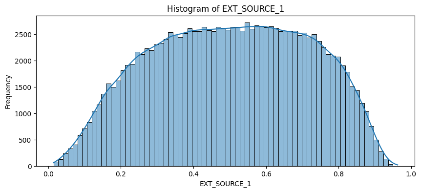

```
EXT_SOURCE_1 seems Gaussian.
```

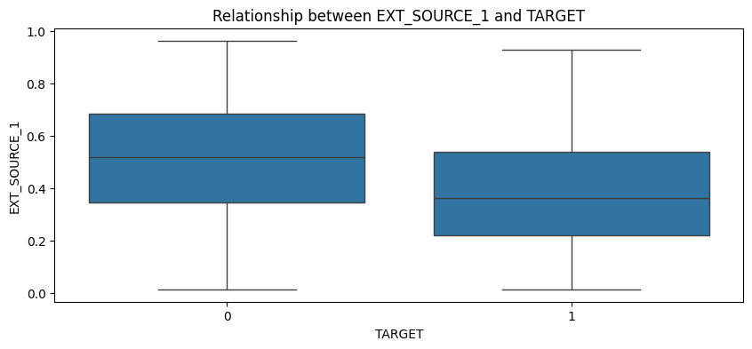

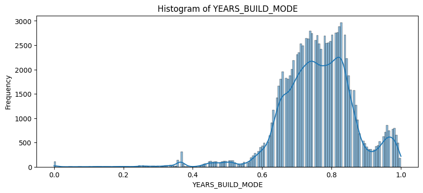

```
YEARS_BUILD_MODE has severe skew.
```

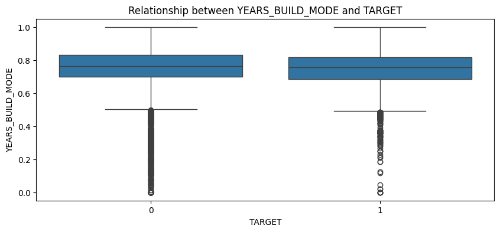

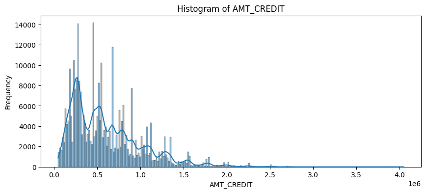

```
AMT_CREDIT has severe skew.
```

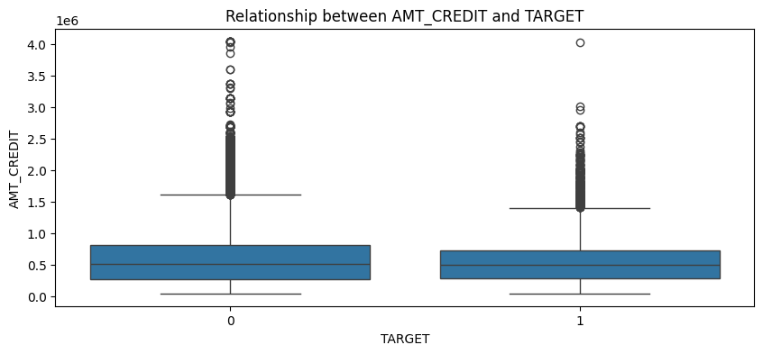

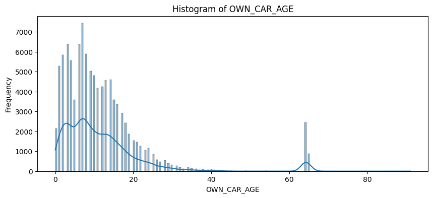

```
OWN_CAR_AGE has severe skew.
```

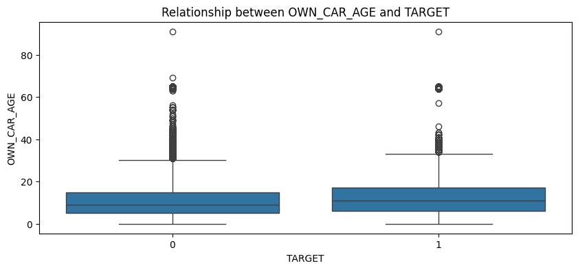

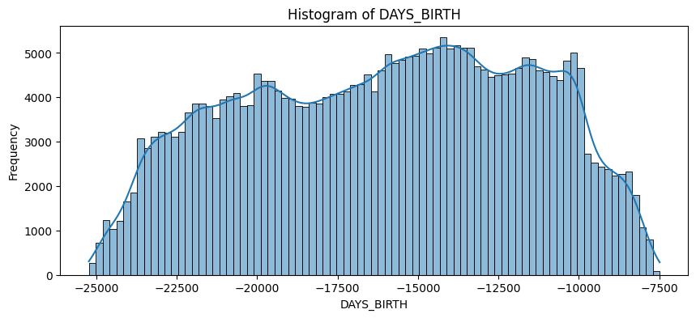

```
DAYS_BIRTH seems Gaussian.
```

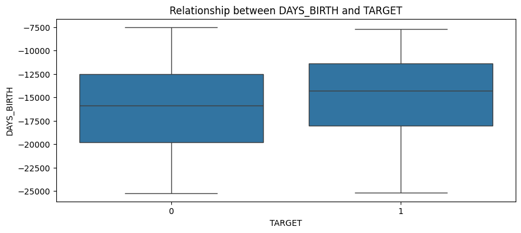

```python
# List of selected features
selected_features = [
    'EXT_SOURCE_1',
    'YEARS_BUILD_MODE',
    'AMT_CREDIT',
    'OWN_CAR_AGE',
    'DAYS_BIRTH'
]

# Generate histograms for each of the selected features
for feature in selected_features:
    plt.figure(figsize=(10, 4))
    sns.histplot(application_train[feature].dropna(), kde=True)
    plt.title(f'Histogram of {feature}')
    plt.xlabel(feature)
    plt.ylabel('Frequency')
    plt.show()

    # Determine the skewness
    skewness = application_train[feature].skew()
    if skewness > 1 or skewness < -1:
        print(f"{feature} has severe skew.")
    elif -0.5 <= skewness <= 0.5:
        print(f"{feature} seems Gaussian.")
    else:
        print(f"{feature} is somewhat skewed.")

    # Visualize the relationship with the target variable
    plt.figure(figsize=(10, 4))
    sns.boxplot(x='TARGET', y=feature, data=application_train)
    plt.title(f'Relationship between {feature} and TARGET')
    plt.show()
    print()
```

Findings: DAYS_BIRTH and EXT_SOURCE_1 seems to be Gaussian whereas AMT_CREDIT, OWN_CAR_AGE and YEARS_BUILD_MODE have severe skew.

### 5. Outlier Analysis: Perform outlier analysis on the chosen variables.

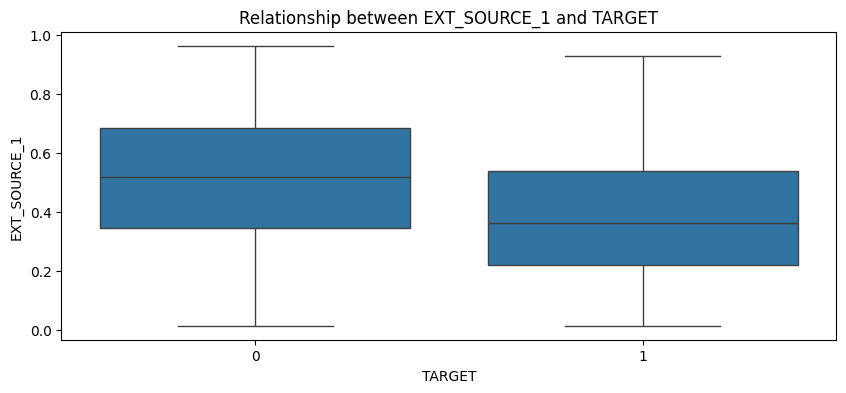

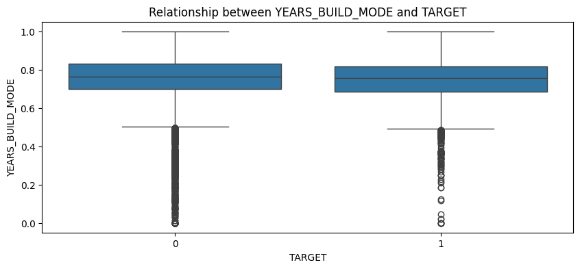

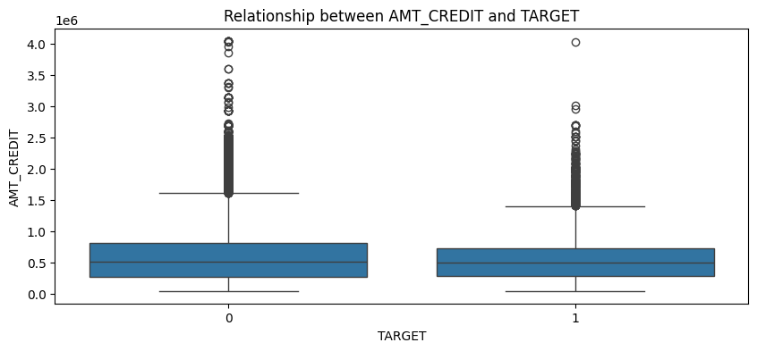

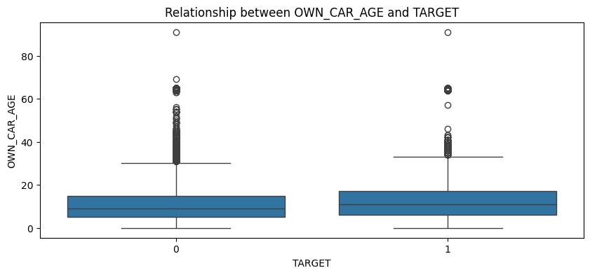

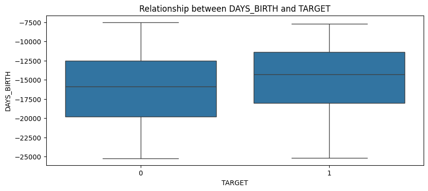

```python
for feature in selected_features:
    plt.figure(figsize=(10, 4))
    sns.boxplot(x='TARGET', y=feature, data=application_train)
    plt.title(f'Relationship between {feature} and TARGET')
    plt.show()
```

### 6.Transformation of Nuemric Variables: If skewed, perform suitable transformations on these five numerical variables. Check the relationship of each of these numeric variables with the target variable using bar charts. Visualize the relationship between each of these numeric variables and the target variable. Perform outlier analysis on the transformed variables and report any differences before and after transformation.

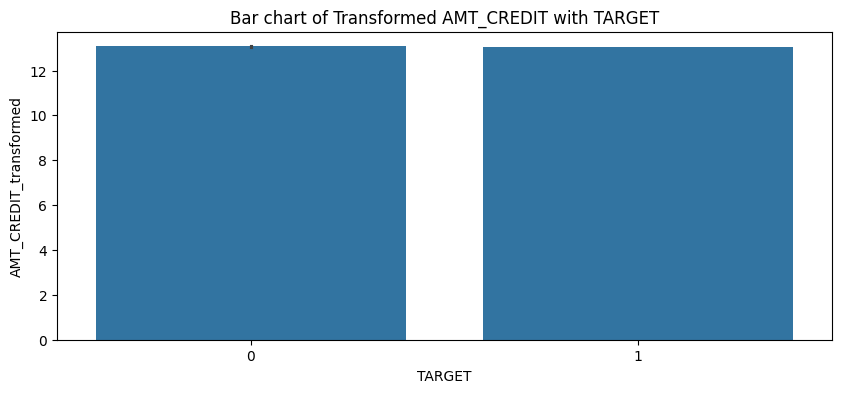

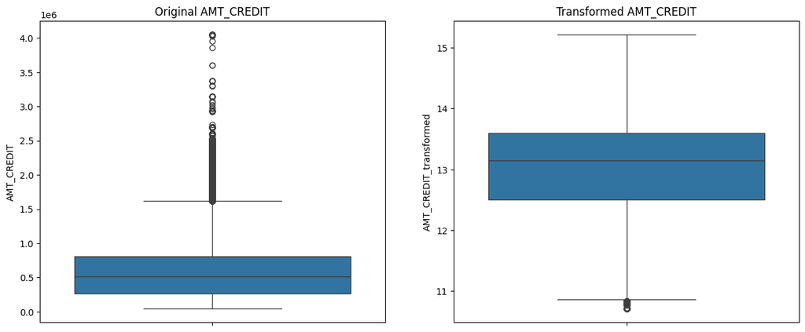

```
AMT_CREDIT: Outliers before transformation: 3255, after transformation: 1212
```

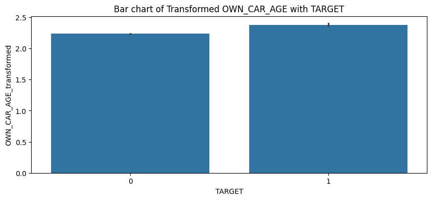

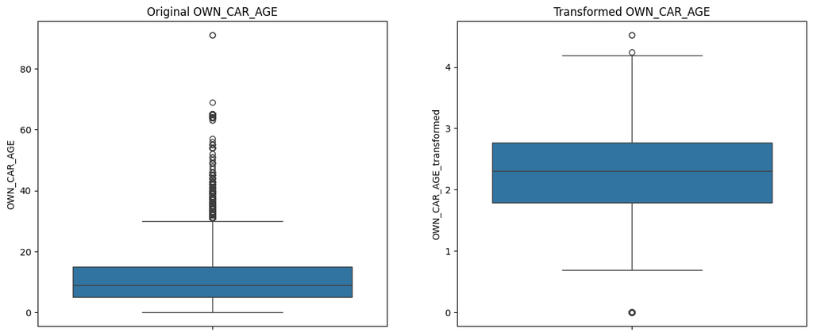

```
OWN_CAR_AGE: Outliers before transformation: 3369, after transformation: 0
```

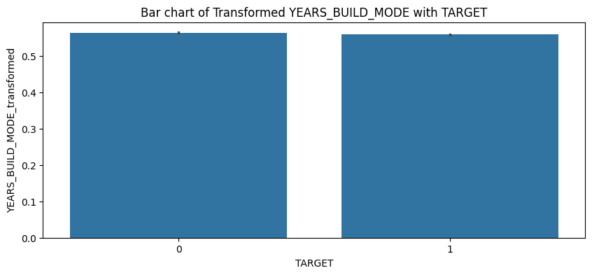

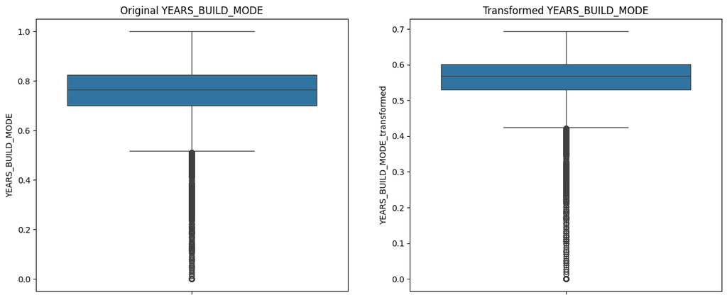

```
YEARS_BUILD_MODE: Outliers before transformation: 1208, after transformation: 1327
```

```python
from scipy.stats import boxcox
from scipy import stats

# Skewed features
skewed_features = ['AMT_CREDIT', 'OWN_CAR_AGE', 'YEARS_BUILD_MODE']

# Apply log transformations to reduce skewness
for feature in skewed_features:
    # Check for values less than or equal to zero before applying log transformation
    if (application_train[feature] <= 0).any():
        # Shift the data to be strictly positive
        application_train[feature+'_transformed'] = np.log(application_train[feature] + 1 - application_train[feature].min())
        application_test[feature+'_transformed'] = np.log(application_test[feature] + 1 - application_test[feature].min())
    else:
        # Apply log transformation directly
        application_train[feature+'_transformed'] = np.log(application_train[feature])
        application_test[feature+'_transformed'] = np.log(application_test[feature])

    # Visualize the relationship with the target variable with a bar chart
    plt.figure(figsize=(10, 4))
    sns.barplot(x='TARGET', y=feature+'_transformed', data=application_train)
    plt.title(f'Bar chart of Transformed {feature} with TARGET')
    plt.show()

    # Outlier analysis using box plots before and after transformation
    plt.figure(figsize=(15, 6))
    plt.subplot(1, 2, 1)
    sns.boxplot(y=application_train[feature].dropna())
    plt.title(f'Original {feature}')

    plt.subplot(1, 2, 2)
    sns.boxplot(y=application_train[feature+'_transformed'].dropna())
    plt.title(f'Transformed {feature}')
    plt.show()
    # calculating the number of outliers using z-score
    z_original = np.abs(stats.zscore(application_train[feature].dropna()))
    z_transformed = np.abs(stats.zscore(application_train[feature+'_transformed'].dropna()))

    outliers_original = (z_original > 3).sum()
    outliers_transformed = (z_transformed > 3).sum()

    print(f"{feature}: Outliers before transformation: {outliers_original}, after transformation: {outliers_transformed}")
```

```python
application_test.shape
```

```
(48744, 124)
```

### 7. Categorical Features: Check cardinality and rare values of at least five categorical features. Discuss whether each of them is ordinal or nominal. Discuss the suitable methods for encoding each of them.

```python
# Select categorical features to examine
features = [
    'OCCUPATION_TYPE',
    'NAME_EDUCATION_TYPE',
    'NAME_INCOME_TYPE',
    'NAME_FAMILY_STATUS',
    'NAME_HOUSING_TYPE'
]

# Check cardinality and identify rare values
print("Cardinality and Rare Values:\n")
for feature in features:
    unique_values = application_train[feature].nunique()
    value_counts = application_train[feature].value_counts(normalize=True)
    rare_values = value_counts[value_counts < 0.01].index.tolist()  # Values with less than 1% occurrence

    print(f"{feature}:")
    print(f"  Cardinality: {unique_values}")
    if rare_values:
        print(f"  Rare values: {rare_values}")
    else:
        print("  Rare values: None")
    print()
```

```
Cardinality and Rare Values:

OCCUPATION_TYPE:
  Cardinality: 18
  Rare values: ['Low-skill Laborers', 'Waiters/barmen staff', 'Secretaries', 'Realty agents', 'HR staff', 'IT staff']

NAME_EDUCATION_TYPE:
  Cardinality: 5
  Rare values: ['Academic degree']

NAME_INCOME_TYPE:
  Cardinality: 8
  Rare values: ['Unemployed', 'Student', 'Businessman', 'Maternity leave']

NAME_FAMILY_STATUS:
  Cardinality: 6
  Rare values: ['Unknown']

NAME_HOUSING_TYPE:
  Cardinality: 6
  Rare values: ['Office apartment', 'Co-op apartment']
```

Nature of Features and Encoding Methods

OCCUPATION_TYPE: Likely nominal as occupations do not have a natural order. Suitable encoding: One-Hot Encoding or Target Encoding (for high cardinality).

NAME_EDUCATION_TYPE: Ordinal, since educational levels have a natural order from less to more advanced. Suitable encoding: Ordinal Encoding (assign each level a corresponding integer based on its order).

NAME_INCOME_TYPE: Nominal, as these categories do not have an inherent order. Suitable encoding: One-Hot Encoding.

NAME_FAMILY_STATUS: Nominal, since there's no natural order to family status types. Suitable encoding: One-Hot Encoding.

NAME_HOUSING_TYPE: Nominal, as housing types don't have a natural ranking or order. Suitable encoding: One-Hot Encoding.

Discussion

Cardinality: High cardinality features might lead to a large number of columns after one-hot encoding, potentially causing dimensionality issues. In such cases, techniques like Feature Hashing or Target Encoding might be more appropriate.

Rare Values: Handling rare values is crucial to avoid overfitting. They can be grouped into a common "Other" category or handled via Target Encoding, where the encoding reflects the likelihood of the outcome given the feature category.

This approach allows you to examine the specified features in the Home Credit Default Risk dataset systematically, addressing cardinality and rare values, and laying the groundwork for thoughtful feature encoding in your predictive models.

### 8. Utilize previous_application.csv to compute and integrate the count of previous applications per SK_ID_CURR into application_train.csv. Further, create at least five new features from additional files, justifying their selection and aggregation method.

Calculate the number of previous applications each customer has made.

```python
# Count of previous applications per SK_ID_CURR
previous_apps_count = previous_applications.groupby('SK_ID_CURR')['SK_ID_PREV'].count().reset_index(name='PREV_APPS_COUNT')

# Merge the count with application_train
application_train = application_train.merge(previous_apps_count, on='SK_ID_CURR', how='left')
application_test = application_test.merge(previous_apps_count, on='SK_ID_CURR', how='left')
```

Calculates a comprehensive debt-to-credit ratio using the total debt and total credit across all bureau records for each customer.

```python
# Sum debts and credits separately, then calculate ratio
bureau['TOTAL_DEBT'] = bureau.groupby('SK_ID_CURR')['AMT_CREDIT_SUM_DEBT'].transform('sum')
bureau['TOTAL_CREDIT'] = bureau.groupby('SK_ID_CURR')['AMT_CREDIT_SUM'].transform('sum')
bureau['DEBT_CREDIT_RATIO'] = bureau['TOTAL_DEBT'] / bureau['TOTAL_CREDIT'].round(2)

# Keep only the first record to avoid duplicates when merging
debt_credit_ratio = bureau[['SK_ID_CURR', 'DEBT_CREDIT_RATIO']].drop_duplicates().reset_index(drop=True)

# Merge with the main DataFrame
application_train = application_train.merge(debt_credit_ratio, on='SK_ID_CURR', how='left')
application_test = application_test.merge(debt_credit_ratio, on='SK_ID_CURR', how='left')
```

Identify the maximum utilization rate of credit lines across all credit card accounts for each customer.

```python
# Calculate credit utilization ratio and find the maximum for each customer
credit_card_balance['UTILIZATION'] = credit_card_balance['AMT_BALANCE'] / credit_card_balance['AMT_CREDIT_LIMIT_ACTUAL'].round(2)
max_utilization = credit_card_balance.groupby('SK_ID_CURR')['UTILIZATION'].max().reset_index()

# Merge with the main DataFrame
application_train = application_train.merge(max_utilization, on='SK_ID_CURR', how='left')
application_test = application_test.merge(max_utilization, on='SK_ID_CURR', how='left')
```

Maximum Credit Card Utilization from credit_card_balance.csv: Reflects how much credit the customer is using relative to their limits. High utilization can signal financial stress or risk.

```python
# Calculate total payments made and average installment amount
installments_payments['TOTAL_PAYMENTS'] = installments_payments['AMT_INSTALMENT'] * installments_payments['NUM_INSTALMENT_NUMBER']
total_payments = installments_payments.groupby('SK_ID_CURR')['TOTAL_PAYMENTS'].sum().reset_index(name='total_payments_made')
avg_installment = installments_payments.groupby('SK_ID_CURR')['AMT_INSTALMENT'].mean().reset_index(name='avg_installment_amount')
avg_installment['avg_installment_amount'] = avg_installment['avg_installment_amount'].round(2)


# Merge these features with the main DataFrame
application_train = application_train.merge(total_payments, on='SK_ID_CURR', how='left')
application_train = application_train.merge(avg_installment, on='SK_ID_CURR', how='left')
application_test = application_test.merge(total_payments, on='SK_ID_CURR', how='left')
application_test = application_test.merge(avg_installment, on='SK_ID_CURR', how='left')
```

Total Number of Active Credits, This feature provides insight into the current credit commitments of a client. A higher number of active credits might indicate higher debt levels, which could affect the client's ability to service new loans.

```python
# Total number of active credits
total_active_credits = bureau[bureau['CREDIT_ACTIVE'] == 'Active'].groupby('SK_ID_CURR').size().reset_index(name='TOTAL_ACTIVE_CREDITS')
application_train = application_train.merge(total_active_credits, on='SK_ID_CURR', how='left')
application_train['TOTAL_ACTIVE_CREDITS'].fillna(0, inplace=True)  # Assuming no active credits as 0
application_test = application_test.merge(total_active_credits, on='SK_ID_CURR', how='left')
application_test['TOTAL_ACTIVE_CREDITS'].fillna(0, inplace=True)
```

Days Since Last Loan Application. This measures the recency of credit application activity. A short interval since the last application could suggest financial urgency, which might be linked to increased credit risk. Conversely, longer intervals might indicate more stable financial circumstances.

```python
# Days since last loan application
recent_application = previous_applications.groupby('SK_ID_CURR')['DAYS_DECISION'].max().reset_index()
recent_application.rename(columns={'DAYS_DECISION': 'DAYS_SINCE_LAST_APP'}, inplace=True)
recent_application['DAYS_SINCE_LAST_APP'] = recent_application['DAYS_SINCE_LAST_APP'].abs()

# Merge with the main DataFrame
application_train = application_train.merge(recent_application, on='SK_ID_CURR', how='left')
application_train['DAYS_SINCE_LAST_APP'].fillna(-1, inplace=True)  # Fill missing values with -1 if no previous applications
application_test = application_test.merge(recent_application, on='SK_ID_CURR', how='left')
application_test['DAYS_SINCE_LAST_APP'].fillna(-1, inplace=True)
```

```python
application_train.head()
```

|  | SK_ID_CURR | TARGET | NAME_CONTRACT_TYPE | CODE_GENDER | FLAG_OWN_CAR | FLAG_OWN_REALTY | CNT_CHILDREN | AMT_INCOME_TOTAL | AMT_CREDIT | AMT_ANNUITY | ... | AMT_CREDIT_transformed | OWN_CAR_AGE_transformed | YEARS_BUILD_MODE_transformed | PREV_APPS_COUNT | DEBT_CREDIT_RATIO | UTILIZATION | total_payments_made | avg_installment_amount | TOTAL_ACTIVE_CREDITS | DAYS_SINCE_LAST_APP |
| --- | --- | --- | --- | --- | --- | --- | --- | --- | --- | --- | --- | --- | --- | --- | --- | --- | --- | --- | --- | --- | --- |
| 0 | 100002 | 1 | Cash loans | M | N | Y | 0 | 202500.0 | 406597.5 | 24700.5 | ... | 12.915579 | NaN | 0.491092 | 1.0 | 0.284122 | NaN | 2590834.680 | 11559.25 | 2.0 | 606.0 |
| 1 | 100003 | 0 | Cash loans | F | N | N | 0 | 270000.0 | 1293502.5 | 35698.5 | ... | 14.072864 | NaN | 0.590006 | 3.0 | 0.000000 | NaN | 7870131.180 | 64754.59 | 1.0 | 746.0 |
| 2 | 100004 | 0 | Revolving loans | M | Y | Y | 0 | 67500.0 | 135000.0 | 6750.0 | ... | 11.813030 | 3.295837 | NaN | 1.0 | 0.000000 | NaN | 47793.645 | 7096.16 | 0.0 | 815.0 |
| 3 | 100006 | 0 | Cash loans | F | N | Y | 0 | 135000.0 | 312682.5 | 29686.5 | ... | 12.652944 | NaN | NaN | 9.0 | NaN | 0.0 | 2388927.915 | 62947.09 | 0.0 | 181.0 |
| 4 | 100007 | 0 | Cash loans | M | N | Y | 0 | 121500.0 | 513000.0 | 21865.5 | ... | 13.148031 | NaN | NaN | 6.0 | 0.000000 | NaN | 6018658.425 | 12666.44 | 0.0 | 374.0 |

5 rows × 132 columns

```python
application_test.shape
```

```
(48744, 131)
```

```python
application_train.shape
```

```
(307511, 132)
```

### 9. NaN Handling. Document your strategy for managing NaN values, providing rationale for your chosen approach.

Dropping columns with a high precentage of missing values

```python
# Store the DataFrames in a dictionary
dataframes = {
    'application_train': application_train,
    'bureau': bureau,
    'bureau_balance': bureau_balance,
    'application_test': application_test,
    'credit_card_balance': credit_card_balance,
    'installments_payments': installments_payments,
    'previous_applications': previous_applications,
    'sample_submission': sample_submission,
    'POS_Cash_balance': POS_Cash_balance,
    'HomeCredit_columns_description': HomeCredit_columns_description
}

# Function to calculate missing values, zero counts, and their percentages for a DataFrame
def calculate_missing_and_zero_values(df):
    total_missing = df.isnull().sum().sort_values(ascending=False)
    percent_missing = (df.isnull().sum() / df.isnull().count() * 100).sort_values(ascending=False)
    zero_count = (df == 0).sum().sort_values(ascending=False)
    percent_zero = (zero_count / df.shape[0] * 100).sort_values(ascending=False)  # Calculate percentage of zeros
    missing_data = pd.concat([total_missing, percent_missing, zero_count, percent_zero], axis=1,
                             keys=['Total Missing', 'Percent Missing', 'Zero Count', 'Percent Zero'])
    return missing_data.head(20)  # Adjust the number based on how many top results you want to display

# Iterate over the dictionary and print missing values and zero counts for each DataFrame
for name, df in dataframes.items():
    print(f"Missing values and zero counts for {name}:")
    print(calculate_missing_and_zero_values(df), "\n")
```

```
Missing values and zero counts for application_train:
                              Total Missing  Percent Missing  Zero Count  \
UTILIZATION                          221348        71.980515       26586
COMMONAREA_AVG                       214865        69.872297        8442
COMMONAREA_MEDI                      214865        69.872297        8691
COMMONAREA_MODE                      214865        69.872297        9690
NONLIVINGAPARTMENTS_MEDI             213514        69.432963       56097
NONLIVINGAPARTMENTS_MODE             213514        69.432963       59255
NONLIVINGAPARTMENTS_AVG              213514        69.432963       54549
FONDKAPREMONT_MODE                   210295        68.386172           0
LIVINGAPARTMENTS_MEDI                210199        68.354953         433
LIVINGAPARTMENTS_MODE                210199        68.354953         519
LIVINGAPARTMENTS_AVG                 210199        68.354953         418
FLOORSMIN_AVG                        208642        67.848630        2320
FLOORSMIN_MEDI                       208642        67.848630        2351
FLOORSMIN_MODE                       208642        67.848630        2517
YEARS_BUILD_MODE_transformed         204488        66.497784         103
YEARS_BUILD_AVG                      204488        66.497784         102
YEARS_BUILD_MODE                     204488        66.497784         103
YEARS_BUILD_MEDI                     204488        66.497784         101
OWN_CAR_AGE                          202929        65.990810        2134
OWN_CAR_AGE_transformed              202929        65.990810        2134

                              Percent Zero
UTILIZATION                       8.645544
COMMONAREA_AVG                    2.745268
COMMONAREA_MEDI                   2.826240
COMMONAREA_MODE                   3.151107
NONLIVINGAPARTMENTS_MEDI         18.242274
NONLIVINGAPARTMENTS_MODE         19.269229
NONLIVINGAPARTMENTS_AVG          17.738878
FONDKAPREMONT_MODE                0.000000
LIVINGAPARTMENTS_MEDI             0.140808
LIVINGAPARTMENTS_MODE             0.168774
LIVINGAPARTMENTS_AVG              0.135930
FLOORSMIN_AVG                     0.754445
FLOORSMIN_MEDI                    0.764525
FLOORSMIN_MODE                    0.818507
YEARS_BUILD_MODE_transformed      0.033495
YEARS_BUILD_AVG                   0.033170
```

[output cut: 232 more lines]

```
CNT_INSTALMENT             0.000000
SK_ID_PREV                 0.000000
SK_ID_CURR                 0.000000
MONTHS_BALANCE             0.000000
NAME_CONTRACT_STATUS       0.000000
SK_DPD                    97.048131
SK_DPD_DEF                98.860465

Missing values and zero counts for HomeCredit_columns_description:
             Total Missing  Percent Missing  Zero Count  Percent Zero
Special                133        60.730594           0           0.0
Unnamed: 0               0         0.000000           0           0.0
Table                    0         0.000000           0           0.0
Row                      0         0.000000           0           0.0
Description              0         0.000000           0           0.0
```

```python
# Check if zeros are significant in these columns
for col in ['COMMONAREA_AVG', 'COMMONAREA_MEDI', 'COMMONAREA_MODE']:
    zero_count = application_train[col].isin([0]).sum()
    print(f"Zero count in {col}: {zero_count}")
```

```
Zero count in COMMONAREA_AVG: 8442
Zero count in COMMONAREA_MEDI: 8691
Zero count in COMMONAREA_MODE: 9690
```

While these counts are significant, they represent a relatively small portion of the dataset when considering the total number of observations (307511 in application_train). The percentages of zero values are:

COMMONAREA_AVG: ≈ 2.74% COMMONAREA_MEDI: ≈ 2.83% COMMONAREA_MODE: ≈ 3.15%

Given their high missing value count and the relatively low proportion of zero values, it seems most prudent to drop these columns from the dataset:

```python
# Dropping columns with more than 50% missing values
high_missing_cols = ['COMMONAREA_MEDI', 'COMMONAREA_AVG', 'COMMONAREA_MODE']
application_train = application_train.drop(columns=high_missing_cols)
```

Handle Moderate Missing Values For columns like OWN_CAR_AGE where missing might logically mean that the applicant doesn't own a car (thus could be imputed as zero):

```python
application_train['OWN_CAR_AGE'] = application_train['OWN_CAR_AGE'].fillna(0)
```

For other moderate missing values where zero is not a logical value (like LIVINGAPARTMENTS_AVG), use median imputation:

```python
from sklearn.impute import SimpleImputer
median_imputer = SimpleImputer(strategy='median')
application_train['LIVINGAPARTMENTS_AVG'] = median_imputer.fit_transform(application_train[['LIVINGAPARTMENTS_AVG']])
```

Handle Low Missing Values For any numerical columns with low missing values where zero does not make sense (e.g., financial amounts that are missing), median imputation could be appropriate. If zero is a possible and logical value (like in payment columns in installments_payments), then zero can be used:

```python
# Example for handling low missing values in a financial context
if 'AMT_PAYMENT' in application_train.columns:
    application_train['AMT_PAYMENT'] = application_train['AMT_PAYMENT'].fillna(0)
```

Columns with moderate missing values (5-30%) like AMT_CREDIT_SUM_DEBT:

```python
bureau['AMT_CREDIT_SUM_DEBT'] = bureau.groupby('CREDIT_ACTIVE')['AMT_CREDIT_SUM_DEBT'].transform(lambda x: x.fillna(x.median()))
```

For Categorical Columns

Columns with high missing values like FONDKAPREMONT_MODE:

```python
application_test['FONDKAPREMONT_MODE'] = application_test['FONDKAPREMONT_MODE'].fillna('Missing')  # or df['FONDKAPREMONT_MODE'].mode()[0]
```

Special Cases

For columns related to RATE_INTEREST_PRIVILEGED with almost all values missing:

```python
previous_applications = previous_applications.drop(columns=['RATE_INTEREST_PRIVILEGED'])
```

For binary features or flags, like NFLAG_INSURED_ON_APPROVAL:

```python
previous_applications['NFLAG_INSURED_ON_APPROVAL'] = previous_applications['NFLAG_INSURED_ON_APPROVAL'].fillna(0)  # Assuming 0 is neutral or most common
```

Using Predictive Models for Imputation For important features where we want to maintain the data distribution, we might use machine learning models to predict the missing values. This could involve training a model where the target variable is the feature with missing values and the predictors are other features.

When choosing imputation strategies, it's essential to understand the dataset and the context of the missing data. Domain knowledge can play a crucial role in deciding the best course of action. Additionally, always validate the imputation by checking the resulting data distributions and, if applicable, the performance of any predictive models using cross-validation or a hold-out set.

```python
'''dataframes = {
    'application_train': application_train,
    #'bureau': bureau,
    #'bureau_balance': bureau_balance,
    'application_test': application_test,
    #'previous_applications': previous_applications,
    #'sample_submission': sample_submission,
    #'HomeCredit_columns_description': HomeCredit_columns_description
}

# Iterate over the dictionary and save each DataFrame as a CSV
for name, df in dataframes.items():
    csv_path = f'/content/{name}_modified.csv'
    df.to_csv(csv_path, index=False)'''
```

```
"dataframes = {\n    'application_train': application_train,\n    #'bureau': bureau,\n    #'bureau_balance': bureau_balance,\n    'application_test': application_test,\n    #'previous_applications': previous_applications,\n    #'sample_submission': sample_submission,\n    #'HomeCredit_columns_descri…
```

# Supervised Learning Model Project

Identify which type of machine learning problem is it?

The problem in question is a classification problem in machine learning. Specifically, it falls under the category of binary classification. The primary objective is to predict whether a loan applicant will default or not based on various attributes and historical data. The outcome variable for each applicant is binary: "default" (1) or "no default" (0).

Please suggest models that the team may consider for the problem at hand. Suggest at least three models and discuss their pros and cons.

The three models that we have considered are:

1. Logistic Regression:

Pros of Logistic Regression:

- Interpretability: Logistic Regression is highly interpretable, making it easier to understand the relationship between the input variables and the prediction.
- Efficiency: It is computationally efficient and can be quickly implemented, which is beneficial for initial explorations and benchmarks.

Cons of Logistic Regression:

- Assumption of Linearity: It assumes a linear relationship between the independent variables and the logarithm of odds, which may not hold in complex scenarios.
- Performance on Non-linear Problems: It might not perform well if the relationship between variables is non-linear without transformations.
2. Random Forest:

Pros of Random Forest:

- Handling Non-linearity: Capable of handling non-linear relationships between features, making it more versatile.
- Feature Importance: Provides useful insights through feature importance scores, which help in understanding which variables most influence the prediction.

Cons of Random Forest:

- Model Complexity and Size: Can become complex and large, leading to increased computational costs and memory usage.
- Overfitting: If not tuned properly, it can overfit, especially with noisy data.
3. Gradient Boosting Machines (GBM):

Pros of Gradient Boosting:

- Predictive Power: GBMs often provide superior predictive accuracy because they combine multiple weak prediction models to create a strong learner.
- Flexibility: Can optimize on different loss functions and provides several hyperparameter tuning options that can improve model performance.

Cons of Gradient Boosting:

- Training Time: They are generally slower to train because trees are built sequentially.
- Tuning Required: Requires careful tuning of parameters and selection of stopping criteria to prevent overfitting and underfitting.

```python
df = application_train
df.head()
```

|  | SK_ID_CURR | TARGET | NAME_CONTRACT_TYPE | CODE_GENDER | FLAG_OWN_CAR | FLAG_OWN_REALTY | CNT_CHILDREN | AMT_INCOME_TOTAL | AMT_CREDIT | AMT_ANNUITY | ... | AMT_CREDIT_transformed | OWN_CAR_AGE_transformed | YEARS_BUILD_MODE_transformed | PREV_APPS_COUNT | DEBT_CREDIT_RATIO | UTILIZATION | total_payments_made | avg_installment_amount | TOTAL_ACTIVE_CREDITS | DAYS_SINCE_LAST_APP |
| --- | --- | --- | --- | --- | --- | --- | --- | --- | --- | --- | --- | --- | --- | --- | --- | --- | --- | --- | --- | --- | --- |
| 0 | 100002 | 1 | Cash loans | M | N | Y | 0 | 202500.0 | 406597.5 | 24700.5 | ... | 12.915579 | NaN | 0.491092 | 1.0 | 0.284122 | NaN | 2590834.680 | 11559.25 | 2.0 | 606.0 |
| 1 | 100003 | 0 | Cash loans | F | N | N | 0 | 270000.0 | 1293502.5 | 35698.5 | ... | 14.072864 | NaN | 0.590006 | 3.0 | 0.000000 | NaN | 7870131.180 | 64754.59 | 1.0 | 746.0 |
| 2 | 100004 | 0 | Revolving loans | M | Y | Y | 0 | 67500.0 | 135000.0 | 6750.0 | ... | 11.813030 | 3.295837 | NaN | 1.0 | 0.000000 | NaN | 47793.645 | 7096.16 | 0.0 | 815.0 |
| 3 | 100006 | 0 | Cash loans | F | N | Y | 0 | 135000.0 | 312682.5 | 29686.5 | ... | 12.652944 | NaN | NaN | 9.0 | NaN | 0.0 | 2388927.915 | 62947.09 | 0.0 | 181.0 |
| 4 | 100007 | 0 | Cash loans | M | N | Y | 0 | 121500.0 | 513000.0 | 21865.5 | ... | 13.148031 | NaN | NaN | 6.0 | 0.000000 | NaN | 6018658.425 | 12666.44 | 0.0 | 374.0 |

5 rows × 129 columns

### Undersampling dataset

In the training dataset, we chose to undersample the majority class (class 0) because of the significant class imbalance observed during exploratory data analysis. This imbalance caused the model to favor class 0, resulting in nearly zero recall for class 1. In this specific use case, it's critical to identify the risk of default accurately, making high recall for class 1 a priority. Undersampling the majority class aims to create a balanced distribution, enabling the model to better recognize patterns associated with defaults (class 1) and, thus, improving its ability to detect these instances.

```python
total_count = len(df)

# Desired target proportions
target_proportion_class_0 = 0.10
target_proportion_class_1 = 0.90

# Calculate the new target counts based on desired proportions
target_count_class_1 = int(total_count * target_proportion_class_1)
current_count_class_1 = df['TARGET'].value_counts()[1]

# Sample from the majority class (class 0) to adjust closer to target proportion
df_class_0 = df[df['TARGET'] == 0]
df_class_1 = df[df['TARGET'] == 1]

# Determine how many samples to draw from class 0 to achieve the new ratio
# Ensure not to sample more than exists for class 0
target_count_class_0 = int(target_count_class_1 * (target_proportion_class_0 / target_proportion_class_1))
target_count_class_0 = min(target_count_class_0, df_class_0.shape[0])

df_class_0_adjusted = df_class_0.sample(target_count_class_0, random_state=42)
df= pd.concat([df_class_0_adjusted, df_class_1], axis=0)
```

```python
df['TARGET'].value_counts(normalize=True)
```

```
TARGET
0    0.553314
1    0.446686
Name: proportion, dtype: float64
```

```python
df.shape
```

```
(55576, 129)
```

### Building Preprocessor Pipeline

```python
# Define a function to replace infinity with NaN
def replace_infinity(X):
    X = np.where(np.isfinite(X), X, np.nan)
    return X

# Function transformer to apply the function
replace_infinity_transformer = FunctionTransformer(replace_infinity, validate=False)

# Split data into features and target
X = df.drop('TARGET', axis=1)
y = df['TARGET']

# Split data into train and test sets
X_train, X_test, y_train, y_test = train_test_split(X, y, test_size=0.2, random_state=42)

# Define numerical and categorical columns
numerical_cols = X_train.select_dtypes(include=['int64', 'float64']).columns
categorical_cols = X_train.select_dtypes(include=['object', 'category']).columns

# Preprocessing for numerical data
numerical_transformer = Pipeline(steps=[
    ('replace_infinity', replace_infinity_transformer),
    ('imputer', SimpleImputer(strategy='mean')),
    ('scaler', StandardScaler())
])

# Preprocessing for categorical data
categorical_transformer = Pipeline(steps=[
    ('imputer', SimpleImputer(strategy='most_frequent')),
    ('onehot', OneHotEncoder(handle_unknown='ignore'))
])

# Bundle preprocessing for numerical and categorical data
preprocessor = ColumnTransformer(
    transformers=[
        ('num', numerical_transformer, numerical_cols),
        ('cat', categorical_transformer, categorical_cols)
    ])

# Apply preprocessing
X_train_preprocessed = preprocessor.fit_transform(X_train)
X_test_preprocessed = preprocessor.transform(X_test)
```

### Performing Feature Selection Using RandomForest and L1 regularization

```python
# Initialize Random Forest for initial feature selection
rf_for_selection = RandomForestClassifier(n_estimators=200, random_state=42)

# Combine preprocessor and Random Forest in a pipeline
selection_pipeline = Pipeline([
    ('preprocessor', preprocessor),
    ('rf_for_selection', rf_for_selection)
])

# Fit the selection pipeline to compute feature importances
selection_pipeline.fit(X_train, y_train)

# Extract feature importances and compute the threshold
importances = selection_pipeline.named_steps['rf_for_selection'].feature_importances_
threshold_quantile = np.quantile(importances, 0.9)

# Feature selection using computed threshold
feature_selector = SelectFromModel(selection_pipeline.named_steps['rf_for_selection'], threshold=threshold_quantile)

# Preprocess and apply Random Forest-based feature selection
X_train_preprocessed = selection_pipeline.named_steps['preprocessor'].transform(X_train)
X_train_selected = feature_selector.fit_transform(X_train_preprocessed, y_train)

# Preprocess the test data and apply the same Random Forest-based feature selection
X_test_preprocessed = selection_pipeline.named_steps['preprocessor'].transform(X_test)
X_test_selected = feature_selector.transform(X_test_preprocessed)

# Extract feature names after Random Forest selection
all_feature_names = np.concatenate([
    preprocessor.named_transformers_['num'].named_steps['scaler'].get_feature_names_out(numerical_cols),
    preprocessor.named_transformers_['cat'].named_steps['onehot'].get_feature_names_out(categorical_cols)
])
selected_features = all_feature_names[feature_selector.get_support()]

# Create a logistic regression model with L1 regularization
logistic_l1 = LogisticRegression(penalty='l1', solver='liblinear', random_state=42)

# Create a pipeline for L1 regularization and scaling
l1_pipeline = Pipeline([
    ('scaler', StandardScaler()),
    ('logistic_l1', logistic_l1)
])

# Fit the L1 pipeline on the features selected by Random Forest
l1_pipeline.fit(X_train_selected, y_train)

# Get the support for the features based on the coefficients
l1_support = l1_pipeline.named_steps['logistic_l1'].coef_[0] != 0
final_selected_features = selected_features[l1_support]

print("Final Selected Features after L1 regularization:", final_selected_features)

# Extract the features that are selected by the L1 regularization for GridSearchCV
X_train_l1_selected = X_train_selected[:, l1_support]
X_test_l1_selected = X_test_selected[:, l1_support]
```

```
Final Selected Features after L1 regularization: ['SK_ID_CURR' 'AMT_INCOME_TOTAL' 'AMT_CREDIT' 'AMT_ANNUITY'
 'AMT_GOODS_PRICE' 'REGION_POPULATION_RELATIVE' 'DAYS_BIRTH'
 'DAYS_EMPLOYED' 'DAYS_REGISTRATION' 'DAYS_ID_PUBLISH'
 'HOUR_APPR_PROCESS_START' 'EXT_SOURCE_1' 'EXT_SOURCE_2' 'EXT_SOURCE_3'
 'DAYS_LAST_PHONE_CHANGE' 'AMT_REQ_CREDIT_BUREAU_YEAR'
 'AMT_CREDIT_transformed' 'OWN_CAR_AGE_transformed' 'PREV_APPS_COUNT'
 'DEBT_CREDIT_RATIO' 'UTILIZATION' 'total_payments_made'
 'avg_installment_amount' 'TOTAL_ACTIVE_CREDITS' 'DAYS_SINCE_LAST_APP']
```

```python
'''# Define the Random Forest model for feature selection
rf_for_selection = RandomForestClassifier(n_estimators=100, random_state=42)

# Combine preprocessor and Random Forest in a pipeline
selection_pipeline = Pipeline([
    ('preprocessor', preprocessor),
    ('rf_for_selection', rf_for_selection)
])

# Fit the selection pipeline to compute feature importances
selection_pipeline.fit(X_train, y_train)

# Extract feature importances and compute the threshold
importances = selection_pipeline.named_steps['rf_for_selection'].feature_importances_
threshold_quantile = np.quantile(importances, 0.85)

# Feature selection using computed threshold
feature_selector = SelectFromModel(selection_pipeline.named_steps['rf_for_selection'], threshold=threshold_quantile)

# Transform the data
X_train_preprocessed = preprocessor.transform(X_train)
X_train_selected = feature_selector.fit_transform(X_train_preprocessed, y_train)
X_test_selected = feature_selector.transform(X_test_preprocessed)
# Extract selected feature names
all_feature_names = np.concatenate([
    preprocessor.named_transformers_['num'].named_steps['scaler'].get_feature_names_out(numerical_cols),
    preprocessor.named_transformers_['cat'].named_steps['onehot'].get_feature_names_out(categorical_cols)
])
selected_features = all_feature_names[feature_selector.get_support()]

print("Selected Features:", selected_features)'''
```

```
'# Define the Random Forest model for feature selection\nrf_for_selection = RandomForestClassifier(n_estimators=100, random_state=42)\n\n# Combine preprocessor and Random Forest in a pipeline\nselection_pipeline = Pipeline([\n    (\'preprocessor\', preprocessor),\n    (\'rf_for_selection\', rf_for_s…
```

### Fitting Logistic Regression Model Using Grid Search

```python
# Model pipelines
logistic_model = LogisticRegression(solver='liblinear',max_iter=2000, random_state=42, tol=0.01)
logistic_pipeline = Pipeline([('logistic', logistic_model)])

# Set up GridSearchCV for each model
param_grid_logistic = {'logistic__C': [0.1,0.3,1,10]}
logistic_grid = GridSearchCV(logistic_pipeline, param_grid_logistic, cv=5, scoring='roc_auc', n_jobs=-1,verbose =2)

# Fit grids using X_train_selected
logistic_grid.fit(X_train_l1_selected, y_train)
# Print best parameters and scores

print("Best parameters and score for logistic regression:", logistic_grid.best_params_, logistic_grid.best_score_)
```

```
Fitting 5 folds for each of 4 candidates, totalling 20 fits
Best parameters and score for logistic regression: {'logistic__C': 10} 0.7396724876743634
```

### Fitting RandomForest and GradientBoostingClassifier using Grid Search

```python
random_forest_model = RandomForestClassifier(random_state=42,class_weight ='balanced')
gbm_model = GradientBoostingClassifier(random_state=42)
rf_pipeline = Pipeline([('rf', random_forest_model)])
gbm_pipeline = Pipeline([('gbm', gbm_model)])

param_grid_rf = {
    'rf__n_estimators': [300,600],
    'rf__max_depth': [None, 10],
    'rf__min_samples_split': [10],
    'rf__min_samples_leaf': [5]
}

param_grid_gbm = {'gbm__n_estimators': [200, 600], 'gbm__learning_rate': [0.1, 0.2]}

rf_grid = GridSearchCV(rf_pipeline, param_grid_rf, cv=3, scoring='roc_auc', n_jobs=-1,verbose =2)
gbm_grid = GridSearchCV(gbm_pipeline, param_grid_gbm, cv=3, scoring='roc_auc', n_jobs=-1,verbose =2)
rf_grid.fit(X_train_l1_selected, y_train)
gbm_grid.fit(X_train_l1_selected, y_train)
print("Best parameters and score for random forest:", rf_grid.best_params_, rf_grid.best_score_)
print("Best parameters and score for GBM:", gbm_grid.best_params_, gbm_grid.best_score_)
```

```
Fitting 3 folds for each of 4 candidates, totalling 12 fits
Fitting 3 folds for each of 4 candidates, totalling 12 fits
Best parameters and score for random forest: {'rf__max_depth': None, 'rf__min_samples_leaf': 5, 'rf__min_samples_split': 10, 'rf__n_estimators': 600} 0.7481818553193312
Best parameters and score for GBM: {'gbm__learning_rate': 0.2, 'gbm__n_estimators': 200} 0.7526024094695778
```

### Evaluating and Comparing Models using ROC_AUC score

Metric Justification:

The ROC-AUC measures the model's ability to distinguish between positive and negative classes by assessing its ability to rank predictions correctly.

- Balanced Evaluation: ROC-AUC evaluates the true positive rate (sensitivity) against the false positive rate across various thresholds. This means it isn't as affected by imbalanced classes as accuracy and can offer insights into the model's predictive capabilities for minority classes, which may be critical in business scenarios where detecting rare events is important.
- Comparative Analysis: Using ROC-AUC makes it easy to compare various models fairly and objectively. It can provide insights into a model's performance over different decision thresholds.

Business Goals:

- Risk Management: The model should aim to minimize the risk of lending to potentially defaulting clients, making ROC-AUC ideal for evaluating this.

```python
# Predict probabilities for the positive class for ROC-AUC
logistic_test_proba = logistic_grid.predict_proba(X_test_l1_selected)[:, 1]
rf_test_proba = rf_grid.predict_proba(X_test_l1_selected)[:, 1]
gbm_test_proba = gbm_grid.predict_proba(X_test_l1_selected)[:, 1]

# Calculate ROC-AUC scores
logistic_test_roc_auc = roc_auc_score(y_test, logistic_test_proba)
rf_test_roc_auc = roc_auc_score(y_test, rf_test_proba)
gbm_test_roc_auc = roc_auc_score(y_test, gbm_test_proba)

print("Test ROC-AUC for Logistic Regression:", logistic_test_roc_auc)
print("Test ROC-AUC for Random Forest:", rf_test_roc_auc)
print("Test ROC-AUC for GBM:", gbm_test_roc_auc)

# Select the best model based on ROC-AUC
best_model = max((logistic_grid, logistic_test_roc_auc),
                 (rf_grid, rf_test_roc_auc),
                 (gbm_grid, gbm_test_roc_auc),
                 key=lambda item: item[1])[0]

print("Best Model on Test Data based on ROC-AUC:", best_model.best_estimator_)
```

```
Test ROC-AUC for Logistic Regression: 0.7298377131289988
Test ROC-AUC for Random Forest: 0.7428643872810718
Test ROC-AUC for GBM: 0.7492278548698164
Best Model on Test Data based on ROC-AUC: Pipeline(steps=[('gbm',
                 GradientBoostingClassifier(learning_rate=0.2, n_estimators=200,
                                            random_state=42))])
```

### Reporting model performance on different metrics

```python
# Report performance on validation data
def report_performance(grid_search, X_test, y_test, model_name):
    print(f"\n=== {model_name} Validation Performance ===")
    print(f"Best Params: {grid_search.best_params_}")
    y_val_pred = grid_search.predict(X_test)
    y_val_prob = grid_search.predict_proba(X_test)[:, 1]
    print(classification_report(y_test, y_val_pred))
    print(f"ROC-AUC Score: {roc_auc_score(y_test, y_val_prob):.4f}")
    print(f"F1 Score: {f1_score(y_test, y_val_pred):.4f}")
    print("\nConfusion Matrix:")
    print(confusion_matrix(y_test, y_val_pred))

# Reporting the performance of each model on validation data
report_performance(logistic_grid, X_test_l1_selected, y_test, "Logistic Regression")
report_performance(rf_grid, X_test_l1_selected, y_test, "Random Forest")
report_performance(gbm_grid, X_test_l1_selected, y_test, "Gradient Boosting")
```

```
=== Logistic Regression Validation Performance ===
Best Params: {'logistic__C': 10}
              precision    recall  f1-score   support

           0       0.68      0.75      0.72      6122
           1       0.66      0.58      0.61      4994

    accuracy                           0.67     11116
   macro avg       0.67      0.66      0.67     11116
weighted avg       0.67      0.67      0.67     11116

ROC-AUC Score: 0.7298
F1 Score: 0.6127

Confusion Matrix:
[[4609 1513]
 [2120 2874]]

=== Random Forest Validation Performance ===
Best Params: {'rf__max_depth': None, 'rf__min_samples_leaf': 5, 'rf__min_samples_split': 10, 'rf__n_estimators': 600}
              precision    recall  f1-score   support

           0       0.71      0.73      0.72      6122
           1       0.65      0.63      0.64      4994

    accuracy                           0.68     11116
   macro avg       0.68      0.68      0.68     11116
weighted avg       0.68      0.68      0.68     11116

ROC-AUC Score: 0.7429
F1 Score: 0.6403

Confusion Matrix:
[[4471 1651]
 [1865 3129]]

=== Gradient Boosting Validation Performance ===
Best Params: {'gbm__learning_rate': 0.2, 'gbm__n_estimators': 200}
              precision    recall  f1-score   support

           0       0.70      0.76      0.73      6122
           1       0.67      0.61      0.64      4994

    accuracy                           0.69     11116
   macro avg       0.69      0.68      0.68     11116
weighted avg       0.69      0.69      0.69     11116

ROC-AUC Score: 0.7492
F1 Score: 0.6383

Confusion Matrix:
[[4642 1480]
 [1959 3035]]
```

### Generating Result and Pickle File

```python
# Generate predictions
best_predictions = best_model.predict(X_test_l1_selected)

# Ensure X_test_l1_selected is in DataFrame format with appropriate feature names
if not isinstance(X_test_l1_selected, pd.DataFrame):
    X_test_l1_selected = pd.DataFrame(X_test_l1_selected, columns=final_selected_features)

# Reset indices to align all data components
X_test_l1_selected = X_test_l1_selected.reset_index(drop=True)
y_test_reset = y_test.reset_index(drop=True)
predictions_df = pd.DataFrame({'Predicted': best_predictions}, index=y_test_reset.index)

# Create a DataFrame for actual and predicted values ensuring the same index
actual_and_predicted_df = pd.DataFrame({
    'Actual': y_test_reset,
    'Predicted': predictions_df['Predicted']
})

# Concatenate feature data with actual and predicted outcomes
results_df = pd.concat([X_test_l1_selected, actual_and_predicted_df], axis=1)

# Ensure the 'Predicted' column is of integer type if required
results_df['Predicted'] = results_df['Predicted'].astype(int)

# Save the DataFrame to CSV
results_df.to_csv('test_predictions.csv', index=False)

# Save the model
joblib.dump(best_model.best_estimator_, 'best_model.pkl')

# Print confirmation message
print("Files saved: test_predictions.csv and best_model.pkl")
```

```
Files saved: test_predictions.csv and best_model.pkl
```